# Basic R Introduction

Ian Plummer

First we need to download the required packages for what we want to do.

```r
#install.packages("ggplot2")
#install.packages("tidyverse")
#install.packages("lubridate")
#install.packages("dbplyr")
library(ggplot2)
library(tidyverse)
library(lubridate)
library(dbplyr)
```

Now we load in the data and set the format for date and time.

```r
data<- read_csv("/Users/ip367316/Downloads/IPWS_202310_202312.csv")
data$DateTime<-  mdy_hm(data$`Date & Time`, tz = "EST") #Tells R how to read the date and time data
```

## Plotting Data

Now we can make a simple plot of the data.

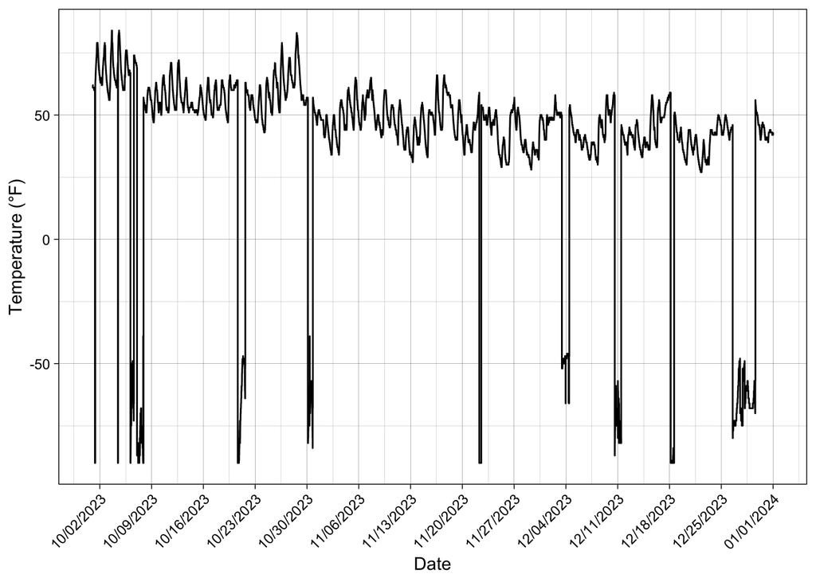

```r
ggplot(data) + geom_line(aes( x = `DateTime`, y = `Temp(F)`)) + #Assigns X and Y values for the plot
  scale_x_datetime(date_labels = ("%m/%d/%Y"), breaks = "1 weeks", guide = guide_axis(angle = 45))+ #Sets date format
  theme_linedraw()+ #Sets the background to a nice pre-set
  xlab("Date") + #Label for Y axis
  ylab("Temperature (°F)") #Label for X axis
```

Below is an example of the same graph but plotting rainfall. Play around with the Y values and see what other variable look like. Make sure you adjuct the ylab accordingly!

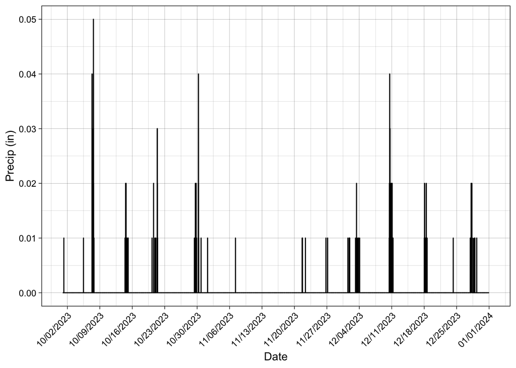

```r
ggplot(data) + geom_line(aes( x = `DateTime`, y = `Rain(in)`)) + #Assigns X and Y values for the plot
  scale_x_datetime(date_labels = ("%m/%d/%Y"), breaks = "1 weeks", guide = guide_axis(angle = 45))+ #Sets date format
  theme_linedraw()+ #Sets the background to a nice pre-set
  xlab("Date") + #Label for Y axis
  ylab("Precip (in)") #Label for X axis
```

## Cleaning Data

Assuming these low temp values are outliers, we use the following code to remove them.

```r
new_data<- data %>% filter(`Temp(F)` > 0)
```

Now we can remake the original plot but with the cleaner data.

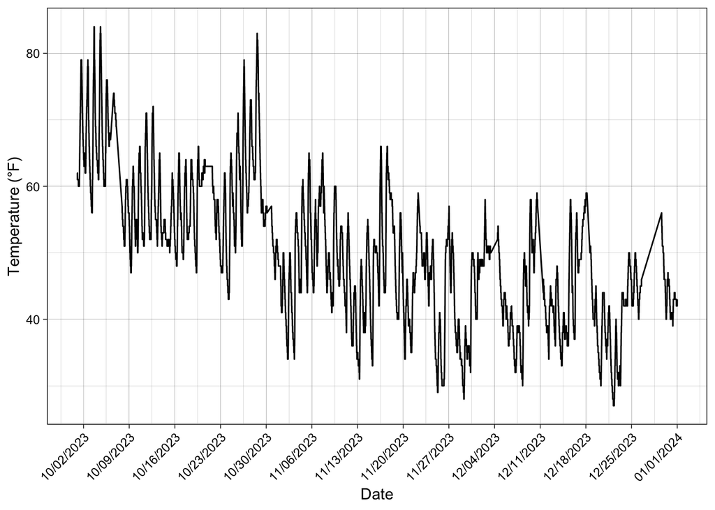

```r
ggplot(new_data) + geom_line(aes( x = `DateTime`, y = `Temp(F)`), ) + #Assigns X and Y values for the plot
  scale_x_datetime(date_labels = ("%m/%d/%Y"), breaks = "1 weeks", guide = guide_axis(angle = 45))+ #Sets date format
  theme_linedraw()+ #Sets the background to a nice pre-set
  xlab("Date") + #Label for Y axis
  ylab("Temperature (°F)") #Label for X axis
```

## Basic Stats

Lets get some basic stats for this filtered temperature data.

```r
mean(new_data$`Temp(F)`) #Calulates the average of the dataset
```

```
## [1] 49.77645
```

```r
sd(new_data$`Temp(F)`) #Calculates the standard deviation of the dataset
```

```
## [1] 10.51128
```

```r
quantile(new_data$`Temp(F)`) #Gives you the quartiles of the dataset
```

```
##   0%  25%  50%  75% 100%
##   27   42   49   57   84
```

We can also begin to explore the relationship between different variables. Lets see how temperature and solar radiation are related to each other.

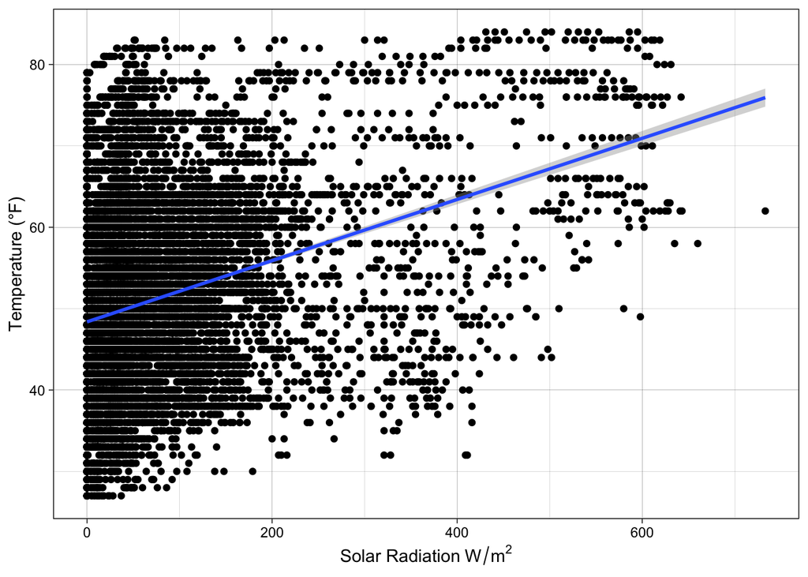

```r
ggplot(new_data) + geom_point(aes(x = `Solar_Rad(W/m^2)`, y = `Temp(F)`)) +
  geom_smooth(aes(x = `Solar_Rad(W/m^2)`, y = `Temp(F)`), method = "lm") + #This adds a trendline
  theme_linedraw()+ #Sets the background to a nice pre-set
  xlab(expression ("Solar Radiation"~W/m^2)) + #Label for Y axis
  ylab("Temperature (°F)") #Label for X axis
```

R does not give you the equation and r2 value of the trendline by default. Lets calculate it using simple linear rgeression

```r
trendline<- lm(new_data$`Temp(F)`~ new_data$`Solar_Rad(W/m^2)`)
summary(trendline)
```

```
##
## Call:
## lm(formula = new_data$`Temp(F)` ~ new_data$`Solar_Rad(W/m^2)`)
##
## Residuals:
##    Min     1Q Median     3Q    Max
## -31.83  -7.38  -0.38   6.62  32.70
##
## Coefficients:
##                              Estimate Std. Error t value Pr(>|t|)
## (Intercept)                 4.838e+01  7.165e-02  675.27   <2e-16 ***
## new_data$`Solar_Rad(W/m^2)` 3.759e-02  8.095e-04   46.44   <2e-16 ***
## ---
## Signif. codes:  0 '***' 0.001 '**' 0.01 '*' 0.05 '.' 0.1 ' ' 1
##
## Residual standard error: 10.07 on 23966 degrees of freedom
## Multiple R-squared:  0.08254,    Adjusted R-squared:  0.08251
## F-statistic:  2156 on 1 and 23966 DF,  p-value: < 2.2e-16
```

We may also want to simply test the correlation, r, between these two variables.

```r
cor(new_data$`Temp(F)`,new_data$`Solar_Rad(W/m^2)`) #This will calculate and print the r value
```

```
## [1] 0.2873056
```

## Bonus

One last fun graph you may be interested in making is a wind rose diagram. Here we have to turn to another package and do some data processing.

```r
#install.packages("openair")
library(openair)
```

```r
new_data_wr<- new_data %>%
  filter(Wind_Direction != "NA")
```

```r
new_data_wr$WD<- case_when(new_data_wr$Wind_Direction == "N" ~ 360,
                                new_data_wr$Wind_Direction  == "NNE" ~ 22.5,
                                new_data_wr$Wind_Direction  == "NE" ~ 45,
                                new_data_wr$Wind_Direction  == "ENE" ~ 67.5,
                                new_data_wr$Wind_Direction  == "E" ~ 90,
                                new_data_wr$Wind_Direction  == "ESE" ~ 112.5,
                                new_data_wr$Wind_Direction  == "SE" ~ 135,
                                new_data_wr$Wind_Direction  == "SSE" ~ 157.5,
                                new_data_wr$Wind_Direction  == "S" ~ 180,
                                new_data_wr$Wind_Direction  == "SSW" ~ 202.5,
                                new_data_wr$Wind_Direction  == "SW" ~ 225,
                                new_data_wr$Wind_Direction == "WSW" ~ 247.5,
                                new_data_wr$Wind_Direction  == "W" ~ 270,
                                new_data_wr$Wind_Direction  == "WNW" ~ 292.5,
                                new_data_wr$Wind_Direction  == "NW" ~ 315,
                                new_data_wr$Wind_Direction  == "NNW" ~ 337.5 )
```

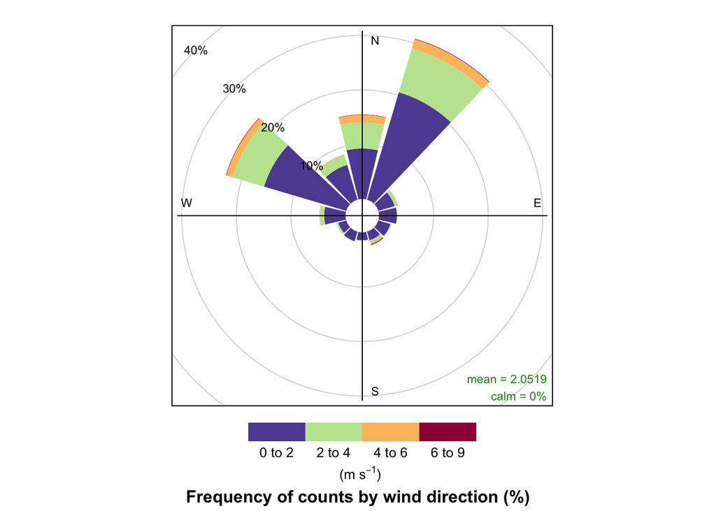

```r
windRose(new_data_wr, ws = "Wind_Speed(mph)", wd = "WD", paddle = F)
```